# Final Project workbook

```r
# Load in data
hires_2019_clean <- read_csv('../clean_data/hires_2019_clean.csv')
rain_2019_clean <- read_csv('../clean_data/rain_2019_clean.csv')
```

```r
# number of stations in total: 164
hires_2019_clean %>%
  distinct(start_station_id) %>%
  count()
```

| n |
| --- |
| 163 |

```r
hires_2019_clean %>%
  distinct(end_station_id) %>%
  count()
```

| n |
| --- |
| 164 |

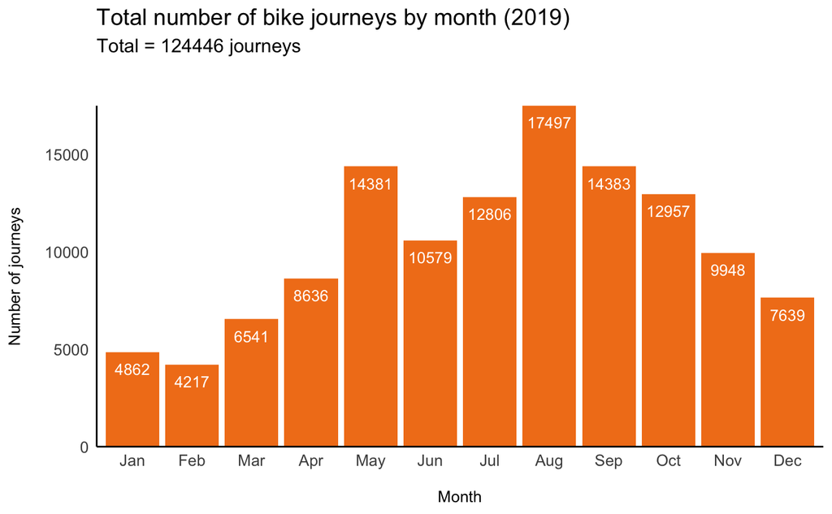

```r
# visualising use by month
hires_2019_clean %>%
  mutate(month = month(start_date, label = TRUE), .before = 1) %>%
  group_by(month) %>%
  summarise(count = n()) %>%
  ggplot() +
  aes(x = month, y = count) +
  geom_col(fill = "#F27F1B") +
  geom_text(aes(label = count), vjust = 2, colour = "white", size = 3.5) +
  labs(x = "\nMonth",
       y = "Number of journeys\n",
       title = "Total number of bike journeys by month (2019)",
       subtitle = "Total = 124446 journeys\n\n") +
  scale_y_discrete(expand = c(0,1), limits = c(0, 5000, 10000, 15000)) +
  theme_minimal() +
  theme(title = element_text(size = 12),
        axis.text = element_text(size = 10),
        axis.title.x = element_text(size = 10),
        axis.title.y = element_text(size = 10),
        panel.grid.major = element_blank(),
        panel.grid.minor = element_blank(),
        panel.background = element_blank(),
        axis.line = element_line(colour = "black"))
```

```r
# create smaller dataset for map
map_data <- hires_2019_clean %>%
  select(start_station_longitude, start_station_latitude, start_station_id, start_station_name, start_elevation) %>%
  distinct(start_station_id, .keep_all = TRUE)
```

```r
map_data %>%
  leaflet() %>%
  addProviderTiles(providers$CartoDB.Positron) %>%
  addTiles(providers$CartoDB.Positron) %>%
  addCircles(lng = ~start_station_longitude,
             lat = ~start_station_latitude,
             color = "#F27F1B",
             popup = ~paste0("Station ID: ", start_station_id,
                             "<br>Name: ", start_station_name,
                             "<br>Elevation (m): ", start_elevation))
```

[interactive chart not shown]

### Most popular stations

```r
# top 10 start and end stations
hires_2019_clean %>%
  select(start_station_id, start_station_name, start_station_description, start_elevation) %>%
  count(start_station_id, start_station_name, start_station_description, start_elevation) %>%
  arrange(desc(n)) %>%
  head(10)
```

| start_station_id | start_station_name | start_station_description | start_elevation | n |
| --- | --- | --- | --- | --- |
| 248 | Bristo Square | Bristo Square, near Potterrow | 92.06 | 6542 |
| 259 | St Andrew Square | North East corner | 76.04 | 5441 |
| 265 | Meadows East | Melville Terrace | 80.45 | 4455 |
| 289 | Castle Street | Near Rose Street | 71.99 | 3908 |
| 257 | Portobello | Edinburgh Leisure Tumbles Centre | 4.30 | 3494 |
| 262 | Canonmills | near Tesco's | 21.12 | 3494 |
| 249 | Fountainbridge | Fountainbridge by Gardner's Crescent | 74.97 | 3208 |
| 247 | Charlotte Square | North Corner of Charlotte Square | 67.62 | 3186 |
| 171 | George Square | George Square, south side in front of University library | 85.16 | 3015 |
| 183 | Waverley Bridge | near the top of the South ramp | 67.62 | 2939 |

```r
hires_2019_clean %>%
  select(end_station_id, end_station_name, end_station_description, end_elevation) %>%
  count(end_station_id, end_station_name, end_station_description, end_elevation) %>%
  arrange(desc(n)) %>%
  head(10)
```

| end_station_id | end_station_name | end_station_description | end_elevation | n |
| --- | --- | --- | --- | --- |
| 262 | Canonmills | near Tesco's | 21.12 | 4760 |
| 257 | Portobello | Edinburgh Leisure Tumbles Centre | 4.30 | 4648 |
| 250 | Victoria Quay | Entrance to Scottish Government Office | 8.23 | 4370 |
| 265 | Meadows East | Melville Terrace | 80.45 | 4088 |
| 248 | Bristo Square | Bristo Square, near Potterrow | 92.06 | 4065 |
| 358 | Leith Walk | Leith Walk opposite Dalmeny Street | 20.96 | 3432 |
| 259 | St Andrew Square | North East corner | 76.04 | 3334 |
| 183 | Waverley Bridge | near the top of the South ramp | 67.62 | 2962 |
| 171 | George Square | George Square, south side in front of University library | 85.16 | 2948 |
| 258 | Stockbridge | Hamilton Place by Dean Bank Lane | 22.22 | 2847 |

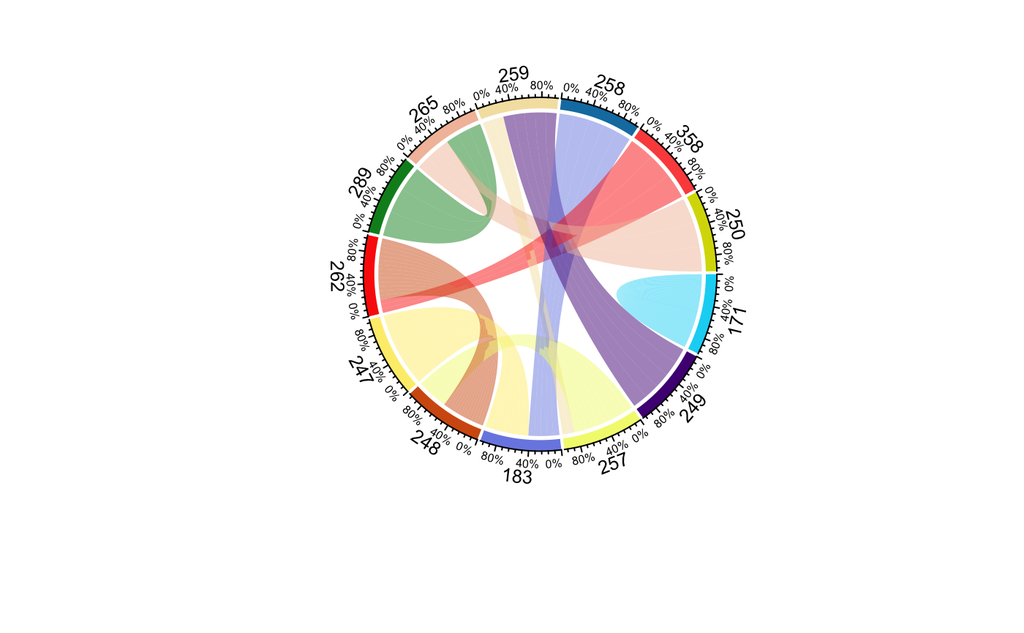

```r
hires_2019_clean %>%
  select(start_station_id, end_station_id) %>%
  filter(start_station_id == c("248", "259", "265", "289", "257", "262", "249", "247", "171", "183"),
         end_station_id == c("262", "257", "250", "265", "248", "358", "259", "183", "171", "258")) %>%
  chordDiagram(scale = TRUE)
```

```r
hires_2019_clean %>%
  filter(start_station_id == "171", end_station_id == "171") %>%
  count()
```

| n |
| --- |
| 239 |

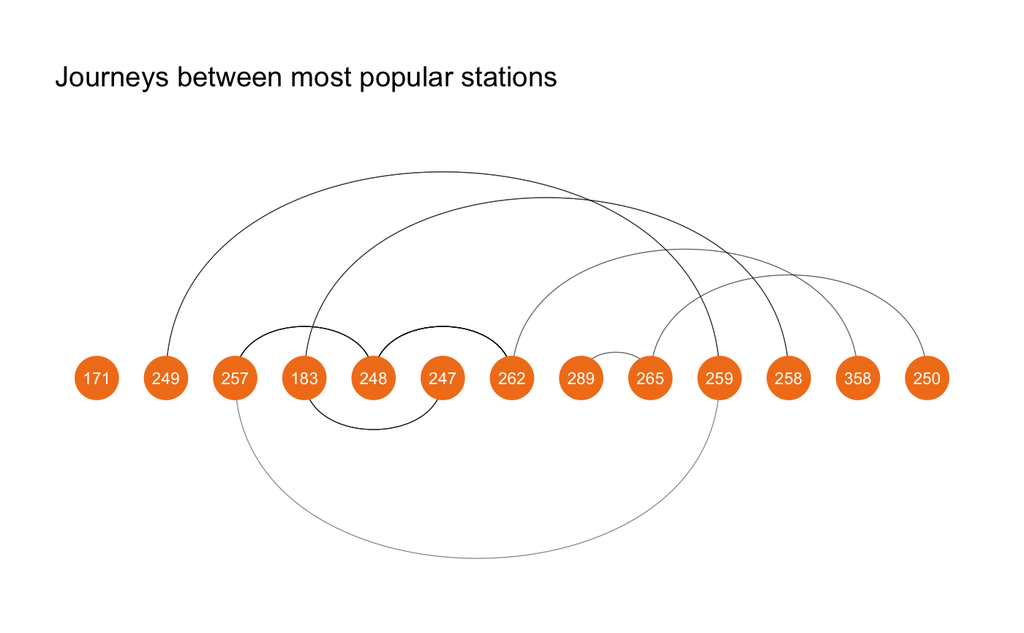

```r
hires_2019_clean %>%
  select(start_station_id, end_station_id) %>%
  filter(start_station_id == c("248", "259", "265", "289", "257", "262", "249", "247", "171", "183"),
         end_station_id == c("262", "257", "250", "265", "248", "358", "259", "183", "171", "258")) %>%
  ggraph(layout = "linear") +
  geom_edge_arc(edge_colour = "black", edge_alpha = 0.3, edge_width = 0.2) +
  geom_node_point(color = "#F27F1B", size = 10) +
  geom_node_text(aes(label = name), repel = FALSE, size = 3, nudge_y = 0, colour = "white") +
  labs(title = "Journeys between most popular stations\n\n") +
  theme_void() +
  theme(title = element_text(size = 12),
        legend.position = "none",
        plot.margin = unit(rep(1, 4), "cm"))
```

### Journeys based on elevation

68622 downhill journeys 43774 uphill journeys 12050 flat journeys

```r
# downhill vs uphill vs flat journeys
# based on elevation of start and end stations

# 68153 downhill journeys
hires_2019_clean %>%
  filter(elevation_diff < 0) %>%
  count()
```

| n |
| --- |
| 68622 |

```r
# 43499 uphill journeys
hires_2019_clean %>%
  filter(elevation_diff > 0) %>%
  count()
```

| n |
| --- |
| 43774 |

```r
# 12032 flat journeys
hires_2019_clean %>%
  filter(elevation_diff == 0) %>%
  count()
```

| n |
| --- |
| 12050 |

### Journeys based on weather

According to www.statista.com “A rainday is when one millimetre or more of rain occurs in a day.” Based on this I have classified rainy days as days where rainfall as recorded by www.power.larc.nasa.gov/ was equal to or over 1mm in Edinburgh.

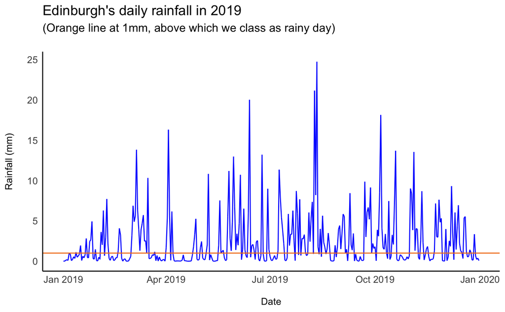

### Hypothesis Test

α = 0.05 H0 - Rain makes no difference to bike hires (number of journeys on rainy days - number of journeys on non rainy days = 0) H1 - Rain has an impact on bike hires (number of journeys on non rainy days - number of journeys on rainy days > 0)

Type of test is one-sample proportion, right-sided.

p value = 0

[output not shown]

[output cut: 355 more lines]

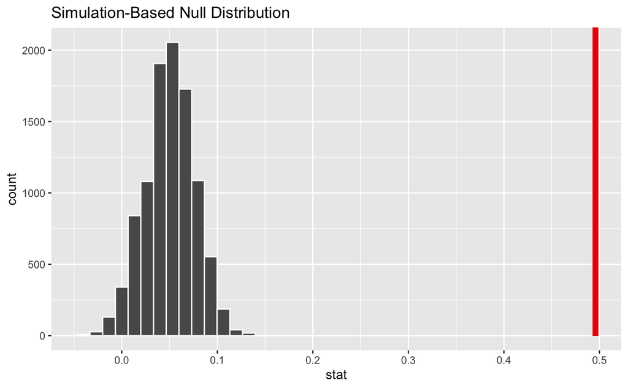

```r
# bootstrapped hypothesis
# α = 0.05
# H0 - Rain makes no difference to bike hires
# H1 - Rain has an impact on bike hires

rain_day_flag <- rain_day %>%
  mutate(rain_day_flag = if_else(rain_day == "TRUE", 1, 0))

null_distribution <- rain_day_flag %>%
  specify(response = rain_day_flag) %>%
  hypothesize(null = "point", mu = 0.05) %>%
  generate(reps = 10000, type = "bootstrap") %>%
  calculate(stat = "mean")

null_distribution %>%
  visualise() +
  shade_p_value(direction = "right", obs_stat = obs_stat)
```

```r
null_distribution %>%
  get_p_value(direction = "right", obs_stat = obs_stat)
```

| p_value |
| --- |
| 0 |

Rainy Days in 2019 = 181 Rainy journeys = 58073 Non rainy journeys = 66373

```r
# count the number of days with rainfall equal to or over 1mm
rain_2019_clean %>%
  filter(rainfall_mm >= 1) %>%
  count()

# journeys based on rainfall
# based on daily precipitation
hires_2019_clean %>%
  filter(rainfall_mm >= 1) %>%
  count()

hires_2019_clean %>%
  filter(rainfall_mm < 1) %>%
  count()
```

### Time of Day analysis

Gym Bunnies - before 7am: 7783 23.07 mins  
Morning Commuters - 7am to 9am: 12452 17.87 mins  
Day Trippers - 9am to 5pm: 66880 29.75 mins  
Homeward Bounders - 5pm to 6.30pm: 14961 23.86 mins  
Evening Movers - 6.30pm to 10pm: 16815 23.5 mins  
Pub Ponies - 10pm to Midnight: 5555 20.67 mins

Average journey time overall is 26.18 minutes

| mean_duration | n |
| --- | --- |
| 26.18 | 124446 |

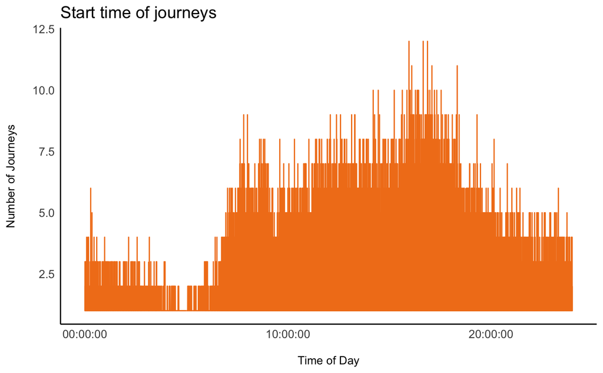